# 4. 이미지자료의 numpy화

### 1. 이미지 자료의 이해

- 구글검색 'jpg, png, gif'
- 3채널이라함은 (행,열,3) / 4채널은 (행,열,4) 로 출력됨
- 3채널은 [[r,g,b],[r,g,b]] 이며 4채널은 [[r,g,b,알파채널],[r,g,b,알파채널]] 임
- png는 상황에 따라 4채널값일수 있음으로 반드시 array할떄 채널수를 확인해야함.
- 구글검색 '파일 헤더' 또는 '파일 시그니처'
  - 파일의 확장자의 무결성 유무는 파일 헤더를 통해 확인해야함. (인공지능에서 사용되는 데이터 값의 일부분 손상이 있을수 있어서 헤더값으로 파일의 손상을 확인할수 있음.)

### 2. PIL 모듈을 이용한 이미지 열기 및 array화

- 구글 검색하여서 PIL 모듈 확인
- 설치는 PILLOW모듈로 설치해야함
  - pip install PILLOW

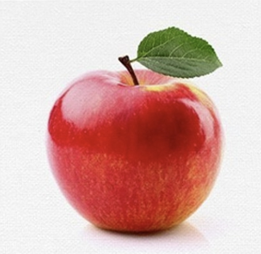

```python
from PIL import Image
img=Image.open('./img/sample.jpg')  # 이미지 열기
img
```

```python
type(img), np.shape(img)   # 행 415, 열 426의 3채널 이미지를 뜻함
```

```
(PIL.JpegImagePlugin.JpegImageFile, (415, 426, 3))
```

```python
import numpy as np
imgArr=np.array(img)
type(imgArr), imgArr[0]     # 1행만 보기
```

```
(numpy.ndarray,
 array([[247, 247, 247],
        [247, 247, 247],
        [248, 248, 248],
        ...,
        [244, 244, 244],
        [246, 246, 246],
        [246, 246, 246]], dtype=uint8))
```

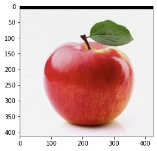

```python
imgArr[:10,:,:]=0    # 위로 10개의 행에 0값 넣는 브로드캐스트

## array 자료는 차트명령어로 출력하여 이미지를 확인함
import matplotlib.pyplot as plt
plt.imshow(imgArr)
```

### 2. 파일 헤더, 파일 시그니처 확인

- 이미지 유형판단
  - https://docs.python.org/ko/3/library/imghdr.html
- 손상된 jpge 파일 복구
  - https://m.blog.naver.com/PostView.naver?isHttpsRedirect=true&blogId=bitnang&logNo=220218322877

```python
import imghdr
print(imghdr.what('./img/sample.jpg'))


# 파일헤더, 파일 시그니처
# 바이너리 형식으로 파일 열기
# jpeg 파일형식: https://yottu.tistory.com/20, https://m.blog.naver.com/nologout/221903980232
with open('./img/sample.jpg','rb') as f:
  data=f.read(16)
data.hex()
```

```
'ffd8ffe000104a464946000101010078'
```

### 3. 여러개의 이미지 확인

- 폴더내의 이미지 파일을 jpg 확장자만 열어서 확인해보면 실제 파일 포맷이 jpg가 아닌 경우가 있음
- 추후 딥러닝 이미지 구축할때 jpg는 3채널, png는 3 또는 4채널이어서 한개의 array가 될수 없는 경우가 있어 문제가 될수 있음.
- 이러한 경우는 이미지 파일을 다시 jpg로 모두 저장하거나 또는 위의 2번에 나온 내용처럼 파일 복구로 헤더값을 통일시키고 작업함

```python
from PIL import Image
from glob import glob
import numpy as np

fileList=glob('./img/*.jpg')   # 작업폴더 하위의 img 폴더의 jpg 파일 보기'

for x in fileList:
    img=Image.open(x)
    print('\n***파일명은:' ,x, '-> 파일헤더를 확인해보니===>' ,imghdr.what(x))

    with open(x,'rb') as f:
      data=f.read(16)
    print(data.hex())
```

```
***파일명은: ./img\lenna.jpg -> 파일헤더를 확인해보니===> png
89504e470d0a1a0a0000000d49484452

***파일명은: ./img\namecard1.jpg -> 파일헤더를 확인해보니===> jpeg
ffd8ffe1136a4578696600004d4d002a

***파일명은: ./img\namecard2.jpg -> 파일헤더를 확인해보니===> jpeg
ffd8ffe112714578696600004d4d002a

***파일명은: ./img\pen.jpg -> 파일헤더를 확인해보니===> jpeg
ffd8ffe000104a46494600010101012c

***파일명은: ./img\poker.jpg -> 파일헤더를 확인해보니===> jpeg
ffd8ffe000104a464946000101000001

***파일명은: ./img\sample.jpg -> 파일헤더를 확인해보니===> jpeg
ffd8ffe000104a464946000101010078

***파일명은: ./img\sudoku.jpg -> 파일헤더를 확인해보니===> jpeg
ffd8ffe000104a464946000102000064

***파일명은: ./img\고등어.jpg -> 파일헤더를 확인해보니===> png
89504e470d0a1a0a0000000d49484452

***파일명은: ./img\합성이미지.jpg -> 파일헤더를 확인해보니===> jpeg
ffd8ffe000104a464946000101010064
```

### 4. 채널수가 다를때 에러 확인

- 여러개의 이미지를 한개의 numpy 자료로 append하면서 작업할떄 채널수가 다르면 에러

```python
# 4채널 있어서 에러 나옴
from PIL import Image
from glob import glob
import numpy as np

fileList=glob('./img/*.jpg')   # 작업폴더 하위의 img 폴더의 jpg 파일 보기
result=[]

for x in fileList:
    img=Image.open(x).resize((100,100))  #이미지를 100,100으로 크기변경


    img=np.array(img)  # 배열로 변경함

    print(x,img.shape)   # shape확인
    result.append(img) # append 해서 여러개의 이미지를 한개의 array에 넣어야 하나, shape이 맞지 않아 에러가 남4

np.shape(result)
```

```
./img\lenna.jpg (100, 100, 3)
./img\namecard1.jpg (100, 100, 3)
./img\namecard2.jpg (100, 100, 3)
./img\pen.jpg (100, 100, 3)
./img\poker.jpg (100, 100, 3)
./img\sample.jpg (100, 100, 3)
./img\sudoku.jpg (100, 100, 3)
./img\고등어.jpg (100, 100, 4)
./img\합성이미지.jpg (100, 100, 3)
```

```
---------------------------------------------------------------------------
AttributeError                            Traceback (most recent call last)
File ~\miniconda3\lib\site-packages\numpy\core\fromnumeric.py:2007, in shape(a)
   2006 try:
-> 2007     result = a.shape
   2008 except AttributeError:

AttributeError: 'list' object has no attribute 'shape'

During handling of the above exception, another exception occurred:

ValueError                                Traceback (most recent call last)
Input In [13], in <cell line: 18>()
     15     print(x,img.shape)   # shape확인
     16     result.append(img) # append 해서 여러개의 이미지를 한개의 array에 넣어야 하나, shape이 맞지 않아 에러가 남4
---> 18 np.shape(result)

File <__array_function__ internals>:180, in shape(*args, **kwargs)

File ~\miniconda3\lib\site-packages\numpy\core\fromnumeric.py:2009, in shape(a)
   2007     result = a.shape
   2008 except AttributeError:
-> 2009     result = asarray(a).shape
   2010 return result

ValueError: could not broadcast input array from shape (100,100,3) into shape (100,100)
```

```python
## 3채널만 append함
## 이렇게 넘파이시킨자료는 npy 자료로 저장가능함
from PIL import Image
from glob import glob
fileList=glob('.\\img\\*.jpg')
result=[]

for x in fileList:
    img=Image.open(x).resize((100,100))

    img=np.array(img)
    if img.shape[2]==3:

        result.append(img)
print(np.shape(result))
print(result[0][0][0]) # 샘플출력, 0~255사이값임
```

```
(8, 100, 100, 3)
[225 136 126]
```

[figure not shown]

```python
import matplotlib.pyplot as plt
plt.figure(figsize=(20,5))
cnt=len(result)
for count,x in enumerate(result):
    plt.subplot(1,cnt,count+1)
    plt.imshow(x)
    plt.title(str(count) +' image')
```

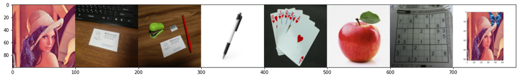

```python
### 또는 연결기능 이용, 단 plt.title이 불가능함
plt.figure(figsize=(20,5))
plt.imshow(np.hstack(result[:]))
```